#Menyiapkan Packages

```r
library(dplyr)
library(TTR)
library(forecast)
library(lmtest) #digunakan untuk uji formal pendeteksian autokorelasi
library(orcutt) #untuk membuat model regresi Cochrane-Orcutt
library(HoRM) #untuk membuat model regresi Hildreth-Lu
```

#Menginput Data

```r
library(rio)
meteor <- import("https://raw.githubusercontent.com/Safwa40/MPDW/main/Pertemuan%202/Cape.csv")
meteor
```

```
##     fips  date PRECTOT     PS  QV2M   T2M T2MDEW T2MWET T2M_MAX T2M_MIN
## 1   1001 42738   18.82  99.69  9.74 14.24  13.44  13.44   18.48    9.29
## 2   1001 42739    0.01 100.02  5.21  8.10   3.86   3.88   11.74    2.12
## 3   1001 42740    0.01  99.89  4.54  5.91   2.20   2.22   13.07   -0.18
## 4   1001 42741   19.85 100.34  3.31  0.35  -2.02  -2.00    4.74   -4.25
## 5   1001 42742    0.06 101.59  1.80 -6.49  -9.40  -9.28   -1.02  -11.57
## 6   1001 42743    0.00 102.36  1.87 -6.38  -9.11  -9.02    0.68  -12.89
## 7   1001 42744    0.00 101.98  2.67 -2.14  -4.85  -4.81    5.20   -9.54
## 8   1001 42745    0.02 101.13  5.62  5.92   4.54   4.55   12.42   -2.37
## 9   1001 42746    0.33 100.81  9.71 14.38  13.49  13.49   20.24    9.97
## 10  1001 42747    0.09 101.03 10.27 15.69  14.45  14.45   22.60   10.66
## 11  1001 42748    0.00 101.50  9.80 16.70  13.88  13.88   23.88   10.98
## 12  1001 42749    0.00 101.42  8.73 16.90  12.09  12.09   23.12   11.37
## 13  1001 42750    0.00 100.95  8.81 15.88  12.17  12.17   21.21   11.65
## 14  1001 42751    0.00 100.73  9.69 15.81  13.55  13.55   22.07   10.72
```

[output cut: 345 more lines]

```r
TS <-meteor$TS
PS <- meteor$PS
QV2M <- meteor$QV2M
T2M <- meteor$T2M
WS10M_RANGE <- meteor$WS10M_RANGE
WS10M <- meteor$WS10M

dtpisah <- data.frame(TS, PS, QV2M, T2M, WS10M_RANGE, WS10M)
```

#Eksplorasi Data

```r
#Membentuk objek time series
meteorts<-ts(meteor$PS)
meteorts
```

```
## Time Series:
## Start = 1
## End = 119
## Frequency = 1
##   [1]  99.69 100.02  99.89 100.34 101.59 102.36 101.98 101.13 100.81 101.03
##  [11] 101.50 101.42 100.95 100.73 100.60 100.49  99.81  99.47  99.02  97.97
##  [21]  98.79  99.72  99.57 100.18 100.60 100.45 100.19 100.52 100.37 100.47
##  [31] 100.66 101.03 101.17 100.75 100.46  99.59  99.36 100.89 101.16 100.58
##  [41] 100.45 100.60  99.79  99.47 100.29 100.18  99.89 100.30 100.44  99.85
##  [51]  99.46  99.49  99.41 100.02 100.68 100.64 100.56 100.09 101.07 101.77
##  [61] 101.78 101.40 101.01 100.79 101.15 100.77 100.55 100.87 100.81 100.26
##  [71] 100.46 101.28 101.37 101.13 100.78 100.93 100.60 100.24 100.57 100.98
##  [81] 100.94 100.43 100.19 100.07  99.99  99.98  99.60  99.67 100.24 100.08
##  [91]  99.28  99.56  99.27 100.08 100.49 100.48 100.50 100.73 100.80 100.78
## [101] 100.76 100.79 100.83 100.70 100.41 100.48 100.67 100.47 100.01  99.67
## [111]  99.53  99.41  99.33  99.26  99.36  99.90 100.16  99.85  99.83
```

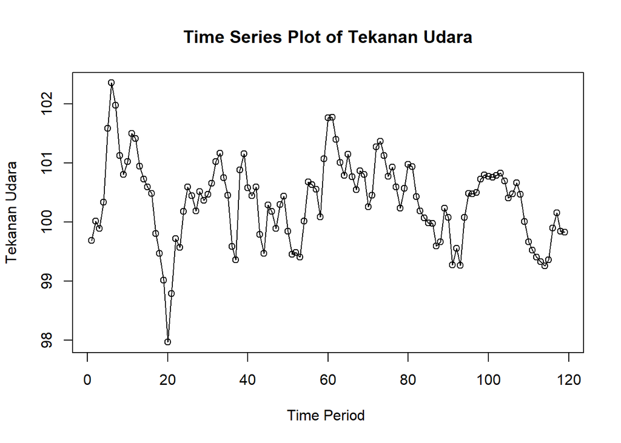

```r
#Membuat plot time series
ts.plot(meteorts, xlab="Time Period ", ylab="Tekanan Udara", main= "Time Series Plot of Tekanan Udara")
points(meteorts)
```

#Membuat Model Regresi

```r
modelmeteor<- lm(TS~PS+QV2M+T2M+WS10M+WS10M_RANGE, data = meteor)
summary(modelmeteor)
```

```
##
## Call:
## lm(formula = TS ~ PS + QV2M + T2M + WS10M + WS10M_RANGE, data = meteor)
##
## Residuals:
##      Min       1Q   Median       3Q      Max
## -1.73384 -0.11427  0.07475  0.21092  0.50697
##
## Coefficients:
##             Estimate Std. Error t value Pr(>|t|)
## (Intercept) 19.71257    6.21790   3.170  0.00196 **
## PS          -0.20177    0.06099  -3.308  0.00126 **
## QV2M        -0.03876    0.03022  -1.283  0.20223
## T2M          1.01793    0.01586  64.185  < 2e-16 ***
## WS10M        0.27388    0.05891   4.649  9.1e-06 ***
## WS10M_RANGE -0.11567    0.05393  -2.145  0.03412 *
## ---
## Signif. codes:  0 '***' 0.001 '**' 0.01 '*' 0.05 '.' 0.1 ' ' 1
##
## Residual standard error: 0.3528 on 113 degrees of freedom
## Multiple R-squared:  0.9969, Adjusted R-squared:  0.9968
## F-statistic:  7353 on 5 and 113 DF,  p-value: < 2.2e-16
```

Berdasarkan uji F hasil didapatkan p-value < 0.05 (alpha) artinya minimal terdapat satu variabel yang berpengaruh nyata terhadap model. Dan uji T didapatkan hasil p-value < 0.05 disemua peubah kecuali QV2M (kelembapan).

#Membuat Plot Sisaan

```r
#sisaan dan fitted value
sisaan<- residuals(modelmeteor)
fitValue<- predict(modelmeteor)
sisaan
```

```
##            1            2            3            4            5            6
## -0.030466722  0.085576231  0.233915729  0.030175024 -0.396990301 -1.258702804
##            7            8            9           10           11           12
## -0.438482451  0.011140145  0.016571380  0.185546444 -0.311372352 -1.733843355
##           13           14           15           16           17           18
## -1.061858671  0.109048095  0.215367503 -0.074328619  0.038968755  0.092815601
##           19           20           21           22           23           24
## -0.020106396 -0.083061093 -0.529523973 -0.208194614 -0.116498157 -0.112034532
##           25           26           27           28           29           30
##  0.347206179  0.370705913  0.145664148  0.189364742  0.069090780  0.123170239
##           31           32           33           34           35           36
##  0.309673761  0.300790549  0.439827430  0.498239774  0.276448495 -0.151710190
##           37           38           39           40           41           42
##  0.152406588  0.209559743  0.214650173  0.052998950  0.034955538 -0.047176760
##           43           44           45           46           47           48
##  0.254856528 -0.317663384 -0.292899312  0.212282592 -0.487701789 -0.829331116
##           49           50           51           52           53           54
##  0.226924472  0.209136924  0.101894755  0.051943939 -0.104978026 -0.198483359
##           55           56           57           58           59           60
##  0.383426544  0.474111746  0.165353863 -0.167867454  0.071902159  0.298853799
##           61           62           63           64           65           66
##  0.404321881  0.372328896  0.131276752  0.126230462 -0.947094405 -0.068626557
##           67           68           69           70           71           72
## -0.041944986  0.307656594  0.335303093  0.456378149  0.140351502  0.506965247
##           73           74           75           76           77           78
## -0.426698539 -0.287752035 -0.011207269 -0.042683178  0.339981351 -0.007130820
##           79           80           81           82           83           84
##  0.129473623  0.226437335  0.172479471  0.218604929  0.092431883  0.074754710
##           85           86           87           88           89           90
## -0.283117698  0.036462452  0.006896093 -0.071629335  0.078713322  0.153015346
##           91           92           93           94           95           96
## -0.235357648  0.194119989 -0.376991689 -0.210684096  0.130096498 -0.399778075
##           97           98           99          100          101          102
##  0.026811735  0.239845744  0.103424240 -0.250202605 -0.020731796  0.167180876
##          103          104          105          106          107          108
##  0.305030898  0.223589311  0.237231858  0.107730811  0.076426602  0.437850775
##          109          110          111          112          113          114
##  0.194061404  0.093227779  0.082586794 -0.275338509 -0.149893934 -0.011700737
##          115          116          117          118          119
## -0.649307964  0.017171881  0.021214994 -0.268065858 -0.163017346
```

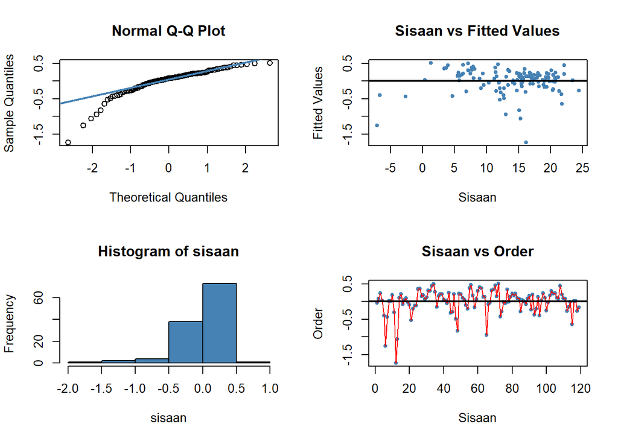

```r
#Diagnostik dengan eksploratif
par(mfrow = c(2,2))
qqnorm(sisaan)
qqline(sisaan, col = "steelblue", lwd = 2)

plot(fitValue, sisaan, col = "steelblue", pch = 20, xlab = "Sisaan", ylab = "Fitted Values", main = "Sisaan vs Fitted Values")
abline(a = 0, b = 0, lwd = 2)

hist(sisaan, col = "steelblue")

plot(seq(1,119,1), sisaan, col = "steelblue", pch = 20, xlab = "Sisaan", ylab = "Order", main = "Sisaan vs Order")
lines(seq(1,119,1), sisaan, col = "red")
abline(a = 0, b = 0, lwd = 2)
```

Kesimpulan yang didapat berdasarkan plot diatas Q-QPlot menunjukan sisaan menyebar tidak normal.

#Melihat Sisaan Menyebar Normal/Tidak H0: sisaan mengikuti sebaran normal H1: sisaan tidak mengikuti sebaran normal

```r
shapiro.test(sisaan)
```

```
##
##  Shapiro-Wilk normality test
##
## data:  sisaan
## W = 0.84805, p-value = 1.04e-09
```

```r
ks.test(sisaan, "pnorm", mean=mean(sisaan), sd=sd(sisaan))
```

```
##
##  Asymptotic one-sample Kolmogorov-Smirnov test
##
## data:  sisaan
## D = 0.14314, p-value = 0.01525
## alternative hypothesis: two-sided
```

Didapatkan kesimpulan data terima H1 atau sebaran tidak normal

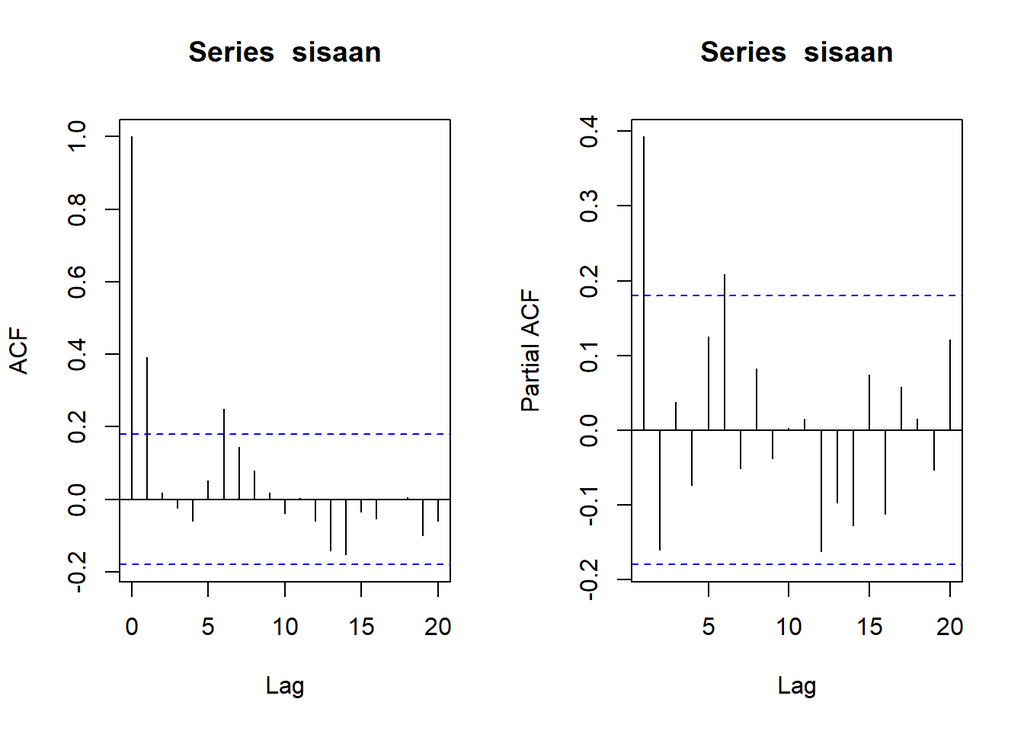

```r
#ACF dan PACF identifikasi autokorelasi
par(mfrow = c(1,2))
acf(sisaan)
pacf(sisaan)
```

Didapatkan kesimpulan bahwa data memiliki auto korelasii

```r
#Deteksi autokorelasi dengan uji-Durbin Watson
#H0: tidak ada autokorelasi
#H1: ada autokorelasi
dwtest(modelmeteor)
```

```
##
##  Durbin-Watson test
##
## data:  modelmeteor
## DW = 1.2128, p-value = 2.315e-06
## alternative hypothesis: true autocorrelation is greater than 0
```

P-value < 0.05 (alpha) sehingga dapat dikategorikan adanya autokorelasi positif pada data.

#Penanganan yang akan digunakan menggunakan dua metode, yaitu Cochrane-Orcutt Penanganan metode Cochrane-Orcutt dapat dilakukan dengan bantuan packages Orcutt pada aplikasi `R` maupun secara manual. Berikut ini ditampilkan cara menggunakan bantuan `library` *packages* `Orcutt`.

```r
#Penanganan Autokorelasi Cochrane-Orcutt
modelCO<-cochrane.orcutt(modelmeteor)
modelCO
```

```
## Cochrane-orcutt estimation for first order autocorrelation
##
## Call:
## lm(formula = TS ~ PS + QV2M + T2M + WS10M + WS10M_RANGE, data = meteor)
##
##  number of interaction: 8
##  rho 0.422379
##
## Durbin-Watson statistic
## (original):    1.21278 , p-value: 2.315e-06
## (transformed): 1.85888 , p-value: 1.832e-01
##
##  coefficients:
## (Intercept)          PS        QV2M         T2M       WS10M WS10M_RANGE
##   20.340032   -0.207249   -0.004304    0.997143    0.238064   -0.113532
```

# Nilai rho optimum tersebut dapat diketahui dengan *syntax* berikut.

```r
#Rho optimum
rho<- modelCO$rho
rho
```

```
## [1] 0.422379
```

# Dilakukan transformasi secara manual dengan syntax berikut ini.

```r
#Transformasi Manual
ps.trans<- PS[-1]-PS[-120]*rho
ts.trans<- TS[-1]-TS[-120]*rho
ws10mr.trans<- WS10M_RANGE[-1]-WS10M_RANGE[-120]*rho
qv2m.trans<- QV2M[-1]-QV2M[-120]*rho
t2m.trans<- T2M[-1]-T2M[-120]*rho
ws10m.trans<- WS10M[-1]-WS10M[-120]*rho
```

# Memubuat model regresi baru dengan data yang telah ditransformasi

```r
modelmeteorCOmanual<- lm(ts.trans~ ps.trans + ws10m.trans + ws10mr.trans + t2m.trans + qv2m.trans)
summary(modelmeteorCOmanual)
```

```
##
## Call:
## lm(formula = ts.trans ~ ps.trans + ws10m.trans + ws10mr.trans +
##     t2m.trans + qv2m.trans)
##
## Residuals:
##      Min       1Q   Median       3Q      Max
## -1.58874 -0.05938  0.04294  0.19543  0.56348
##
## Coefficients:
##               Estimate Std. Error t value Pr(>|t|)
## (Intercept)  11.939941   4.692465   2.544  0.01229 *
## ps.trans     -0.210424   0.079826  -2.636  0.00957 **
## ws10m.trans   0.236764   0.054099   4.377  2.7e-05 ***
## ws10mr.trans -0.113134   0.050416  -2.244  0.02678 *
## t2m.trans     0.996409   0.018253  54.590  < 2e-16 ***
## qv2m.trans   -0.004046   0.031884  -0.127  0.89925
## ---
## Signif. codes:  0 '***' 0.001 '**' 0.01 '*' 0.05 '.' 0.1 ' ' 1
##
## Residual standard error: 0.3226 on 113 degrees of freedom
## Multiple R-squared:  0.9948, Adjusted R-squared:  0.9946
## F-statistic:  4312 on 5 and 113 DF,  p-value: < 2.2e-16
```